# Doctor Type ML Models

Amy Jin

6/12/2018

# 5 Evaluate Some Algorithms

Now it is time to create some models of the data and estimate their accuracy on unseen data. Here are the steps:

- Set-up the evaluaion method.
- Build a couple basic models to predict Y from X.
- Select the best model.

## 5.1 Classification Evaluation Method

Typically ,we are using the metric of “Accuracy” to evaluate models. This is a ratio of the number of correctly predicted instances in divided by the total number of instances in the dataset multiplied by 100 to give a percentage (e.g. 95% accurate). We will be using the metric variable when we run build and evaluate each model next. However, in this case, we have unbalanced data, accuracy is not enough to give us clear idea on the performance. Thus, the following 5 methods are adopted to evaluate predictive models:

- Accuracy
- Confusion Matrix
- ROC
- AIC
- Null Deviance and Residual Deviance

## 5.2 Build Models

We don’t know which algorithms would be good on this problem or what configurations to use. We get an idea from the plots that some of the classes are partially linearly separable in some dimensions, so we are expecting generally good results.

- Logistic Regression
- Linear Discriminant Analysis (LDA)
- Classification and Regression Trees (CART).
- k-Nearest Neighbors (kNN).
- Support Vector Machines (SVM) with a linear kernel.
- Random Forest (RF)

This is a good mixture of simple linear (LDA), nonlinear (CART, kNN, Logistic) and complex nonlinear methods (SVM, RF). We reset the random number seed before reach run to ensure that the evaluation of each algorithm is performed using exactly the same data splits. It ensures the results are directly comparable.

### 5.2.1 Logistic Regression

#### Building the Model

Now, let’s fit the model. Be sure to specify the parameter family=binomial in the glm() function.

```r
model <- glm(Y_is_oncologist ~ X_96413+X_96367+X_96361+X_80053+X_G0008+X_83615+X_82728+X_83550+X_J3490+X_Q2037 ,family=binomial(link='logit'),data=train)
```

Logistic regression model summary is:

```r
summary(model)
```

```
##
## Call:
## glm(formula = Y_is_oncologist ~ X_96413 + X_96367 + X_96361 +
##     X_80053 + X_G0008 + X_83615 + X_82728 + X_83550 + X_J3490 +
##     X_Q2037, family = binomial(link = "logit"), data = train)
##
## Deviance Residuals:
##     Min       1Q   Median       3Q      Max
## -2.8775  -0.0719  -0.0719  -0.0719   4.5133
##
## Coefficients:
##             Estimate Std. Error  z value Pr(>|z|)
## (Intercept) -5.95583    0.05425 -109.794  < 2e-16 ***
## X_96413     12.37764    0.96006   12.893  < 2e-16 ***
## X_96367      6.06042    1.00242    6.046 1.49e-09 ***
## X_96361      9.71591    2.20107    4.414 1.01e-05 ***
## X_80053      1.96696    0.38738    5.078 3.82e-07 ***
## X_G0008     -6.36794    1.26716   -5.025 5.02e-07 ***
## X_83615      0.31371    0.64728    0.485  0.62792
## X_82728      4.14051    1.44581    2.864  0.00419 **
## X_83550      0.75143    1.55913    0.482  0.62984
## X_J3490     -5.40055    3.46293   -1.560  0.11887
## X_Q2037     -2.08781    3.41795   -0.611  0.54131
## ---
## Signif. codes:  0 '***' 0.001 '**' 0.01 '*' 0.05 '.' 0.1 ' ' 1
##
## (Dispersion parameter for binomial family taken to be 1)
##
##     Null deviance: 6304.6  on 148794  degrees of freedom
## Residual deviance: 5490.4  on 148784  degrees of freedom
## AIC: 5512.4
##
## Number of Fisher Scoring iterations: 10
```

```r
## CIs using profiled log-likelihood
confint(model)
```

```
##                   2.5 %    97.5 %
## (Intercept)  -6.0640020 -5.851302
## X_96413      10.4638723 14.236767
## X_96367       4.0421532  8.130018
## X_96361       5.2629387 13.926945
## X_80053       1.1836515  2.702581
## X_G0008      -9.0913491 -4.095774
## X_83615      -0.9927961  1.552296
## X_82728       1.0969595  6.770630
## X_83550      -2.1903574  3.955060
## X_J3490     -12.1614872  1.772952
## X_Q2037      -9.9928968  3.674311
```

```r
## CIs using standard errors
confint.default(model)
```

```
##                   2.5 %    97.5 %
## (Intercept)  -6.0621452 -5.849507
## X_96413      10.4959536 14.259317
## X_96367       4.0957245  8.025125
## X_96361       5.4018903 14.029937
## X_80053       1.2077148  2.726202
## X_G0008      -8.8515289 -3.884357
## X_83615      -0.9549334  1.582353
## X_82728       1.3067806  6.974240
## X_83550      -2.3044171  3.807268
## X_J3490     -12.1877786  1.386673
## X_Q2037      -8.7868638  4.611247
```

#### Performance of Model

How does the model work for unknown test data? There are 5 ways：

```r
fitted.results <- predict(model,newdata=train[5:14],type='response')
fitted.results <- ifelse(fitted.results > 0.5,1,0)
misClasificError <- mean(fitted.results != train$Y_is_oncologist)
print(paste('Accuracy',1-misClasificError))
```

```
## [1] "Accuracy 0.996753923182903"
```

```r
# Use your model to make predictions, in this example newdata = training set
pdata <- predict(model, newdata = train[,5:14], type = "response")
# use caret and compute a confusion matrix
confusionMatrix(data = as.factor(as.numeric(pdata>0.5)), reference = as.factor(train$Y_is_oncologist))
```

```
## Confusion Matrix and Statistics
##
##           Reference
## Prediction      0      1
##          0 148307    461
##          1     22      5
##
##                Accuracy : 0.9968
##                  95% CI : (0.9965, 0.997)
##     No Information Rate : 0.9969
##     P-Value [Acc > NIR] : 0.7923
##
##                   Kappa : 0.0199
##  Mcnemar's Test P-Value : <2e-16
##
##             Sensitivity : 0.99985
##             Specificity : 0.01073
##          Pos Pred Value : 0.99690
##          Neg Pred Value : 0.18519
##              Prevalence : 0.99687
##          Detection Rate : 0.99672
##    Detection Prevalence : 0.99982
##       Balanced Accuracy : 0.50529
##
##        'Positive' Class : 0
##
```

```r
fitted.results <- predict(model,newdata=test[5:14],type='response')
fitted.results <- ifelse(fitted.results > 0.5,1,0)
misClasificError <- mean(fitted.results != test$Y_is_oncologist)
print(paste('Accuracy',1-misClasificError))
```

```
## [1] "Accuracy 0.996505188450992"
```

```r
# Use your model to make predictions, in this example newdata = test set
pdata <- predict(model, newdata = test[,5:14], type = "response")
# use caret and compute a confusion matrix
confusionMatrix(data = as.factor(as.numeric(pdata>0.5)), reference = as.factor(test$Y_is_oncologist))
```

```
## Confusion Matrix and Statistics
##
##           Reference
## Prediction     0     1
##          0 37065   120
##          1    10     3
##
##                Accuracy : 0.9965
##                  95% CI : (0.9959, 0.9971)
##     No Information Rate : 0.9967
##     P-Value [Acc > NIR] : 0.7535
##
##                   Kappa : 0.0435
##  Mcnemar's Test P-Value : <2e-16
##
##             Sensitivity : 0.99973
##             Specificity : 0.02439
##          Pos Pred Value : 0.99677
##          Neg Pred Value : 0.23077
##              Prevalence : 0.99669
##          Detection Rate : 0.99642
##    Detection Prevalence : 0.99965
##       Balanced Accuracy : 0.51206
##
##        'Positive' Class : 0
##
```

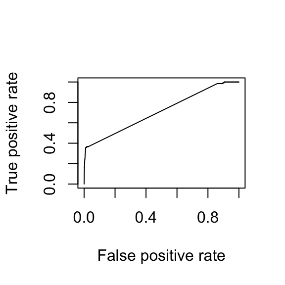

```r
p <- predict(model, newdata=test[5:14], type="response")
pr <- prediction(p, test$Y_is_oncologist)
prf <- performance(pr, measure = "tpr", x.measure = "fpr")
plot(prf)
```

```r
auc <- performance(pr, measure = "auc")
auc <- auc@y.values[[1]]
auc
```

```
## [1] 0.7102439
```

From both confusion matrix and ROC, we can see that logistic regression with the train data is not satisfiying. Either there is nonlinearity or the features of X are not good.

### 5.2.2 LDA

We will use the same set of features that are used in Logistic regression and create the LDA model. The model has the following output as explained below:

```r
attach(train)
lda.model <- lda(factor(train$Y_is_oncologist) ~ X_96413+X_96367+X_96361+X_80053+X_G0008+X_83615+X_82728+X_83550+X_J3490+X_Q2037, data = train)
lda.model
```

```
## Call:
## lda(factor(train$Y_is_oncologist) ~ X_96413 + X_96367 + X_96361 +
##     X_80053 + X_G0008 + X_83615 + X_82728 + X_83550 + X_J3490 +
##     X_Q2037, data = train)
##
## Prior probabilities of groups:
##           0           1
## 0.996868174 0.003131826
##
## Group means:
##      X_96413     X_96367     X_96361    X_80053    X_G0008      X_83615
## 0 0.00113453 0.000652917 0.000205818 0.01474485 0.03274997 0.0007626197
## 1 0.04545697 0.035520315 0.011034030 0.10348567 0.01090800 0.0356493734
##       X_82728      X_83550      X_J3490     X_Q2037
## 0 0.001101443 0.0007443427 0.0002550026 0.004911932
## 1 0.026559410 0.0186654142 0.0035210794 0.002336335
##
## Coefficients of linear discriminants:
##                LD1
## X_96413 30.8475909
## X_96367 37.4196876
## X_96361 43.4087496
## X_80053  0.1621030
## X_G0008 -0.8186111
## X_83615  6.6685934
## X_82728  9.6384490
## X_83550  5.6902762
## X_J3490 -3.1446454
## X_Q2037 -0.1680971
```

#### Performance of Model

```r
##Predicting training results.
predmodel.train.lda = predict(lda.model, data=train[,5:14])
#length(train$Y_is_oncologist)
#length(predmodel.train.lda$class)
table(Predicted=predmodel.train.lda$class, Class=train$Y_is_oncologist)
```

```
##          Class
## Predicted      0      1
##         0 147190    311
##         1   1139    155
```

The below plot shows how the response class has been classified by the LDA classifier. The X-axis shows the value of line defined by the co-efficient of linear discriminant for LDA model. The two groups are the groups for response classes.

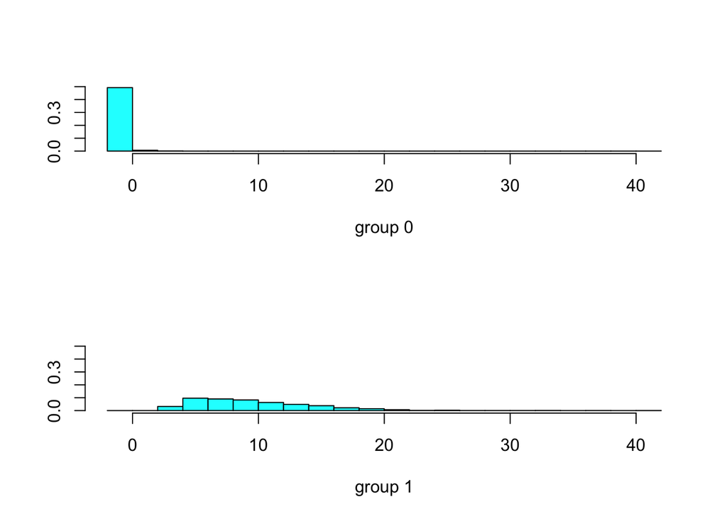

```r
ldahist(predmodel.train.lda$x[,1], g= predmodel.train.lda$class)
```

```r
attach(test)
predmodel.test.lda = predict(lda.model, newdata=test[,5:14])
table(Predicted=predmodel.test.lda$class, Class=test$Y_is_oncologist)
```

```
##          Class
## Predicted     0     1
##         0 36764    81
##         1   311    42
```

The below figure shows how the test data has been classified. The Predicted Group-1 and Group-2 has been colored with actual classification with red and green color. The mix of red and green color in the Group-1 and Group-2 shows the incorrect classification prediction.

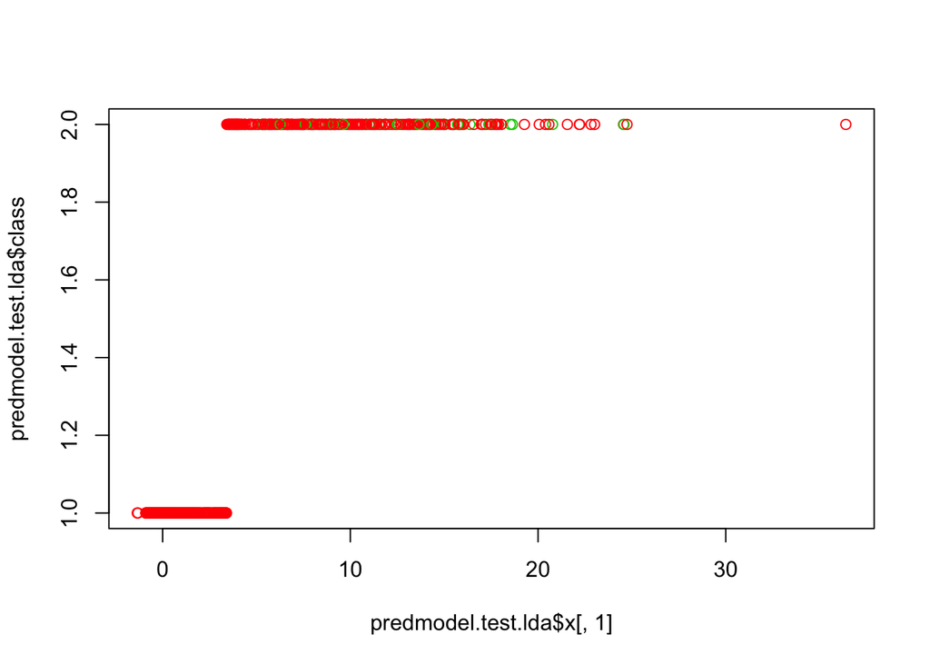

```r
par(mfrow=c(1,1))
plot(predmodel.test.lda$x[,1], predmodel.test.lda$class, col=test$Y_is_oncologist+10)
```

ROC Curve:

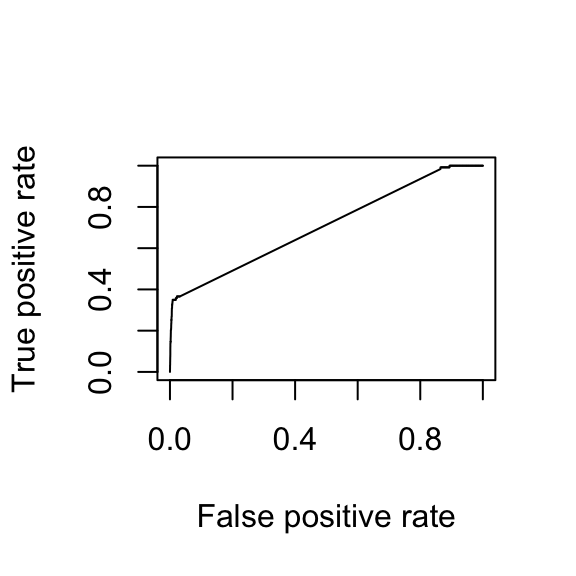

```r
p <- predict(lda.model, newdata=test[5:14], type="response")
pr <- prediction(p$x, as.factor(test$Y_is_oncologist))
prf <- performance(pr, measure = "tpr", x.measure = "fpr")
plot(prf)
```

```r
auc <- performance(pr, measure = "auc")
auc <- auc@y.values[[1]]
auc
```

```
## [1] 0.7074679
```

### 5.2.3 QDA Model

Next we will fit the model to QDA as below. The equation is same as LDA and it outputs the prior probabilities and Group means. Please note that ‘prior probability’ and ‘Group Means’ values are same as of LDA. However, unlike LDA, QDA assumes that each class has its own covariance matrix. In other words, the predictor variables are not assumed to have common variance across each of the k levels in Y.

```r
qda.model <- qda(factor(train$Y_is_oncologist) ~ X_96413+X_96367+X_96361+X_80053+X_G0008+X_83615+X_82728+X_83550+X_J3490+X_Q2037, data = train)
qda.model
```

```
## Call:
## qda(factor(train$Y_is_oncologist) ~ X_96413 + X_96367 + X_96361 +
##     X_80053 + X_G0008 + X_83615 + X_82728 + X_83550 + X_J3490 +
##     X_Q2037, data = train)
##
## Prior probabilities of groups:
##           0           1
## 0.996868174 0.003131826
##
## Group means:
##      X_96413     X_96367     X_96361    X_80053    X_G0008      X_83615
## 0 0.00113453 0.000652917 0.000205818 0.01474485 0.03274997 0.0007626197
## 1 0.04545697 0.035520315 0.011034030 0.10348567 0.01090800 0.0356493734
##       X_82728      X_83550      X_J3490     X_Q2037
## 0 0.001101443 0.0007443427 0.0002550026 0.004911932
## 1 0.026559410 0.0186654142 0.0035210794 0.002336335
```

#### Performance of Model

```r
##Predicting training results.
predmodel.train.qda = predict(qda.model, data=train[,5:14])
table(Predicted=predmodel.train.qda$class, Class=train$Y_is_oncologist)
```

```
##          Class
## Predicted      0      1
##         0 145998    302
##         1   2331    164
```

```r
##Predicting test results.
attach(test)
predmodel.test.qda = predict(qda.model, newdata=test[,5:14])
table(Predicted=predmodel.test.qda$class, Class=test$Y_is_oncologist)
```

```
##          Class
## Predicted     0     1
##         0 36480    78
##         1   595    45
```

The below figure shows how the test data has been classified using the QDA model. The Predicted Class 0 and Class 1 has been colored with actual classification with red and green color. The mix of red and green color in the Class 0 and Class 1 shows the incorrect classification prediction.

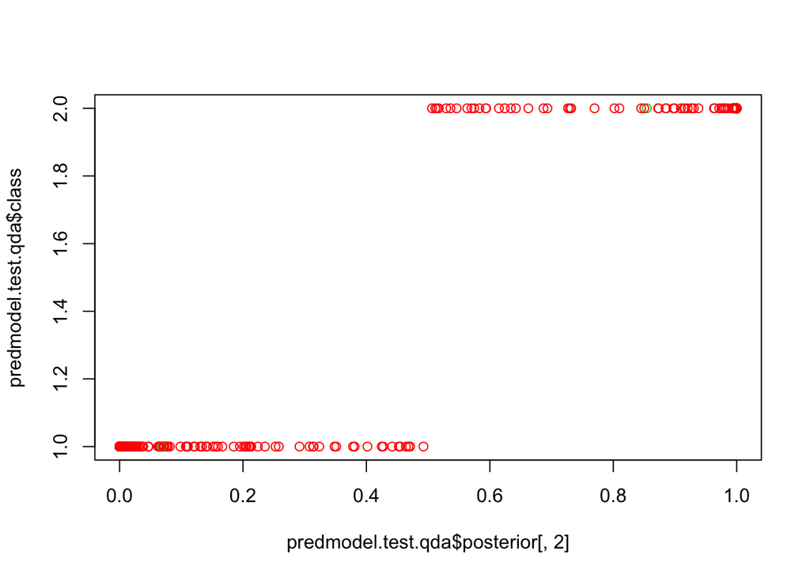

```r
par(mfrow=c(1,1))
plot(predmodel.test.qda$posterior[,2], predmodel.test.qda$class, col=test$Y_is_oncologist+10)
```

ROC curve ans AUC:

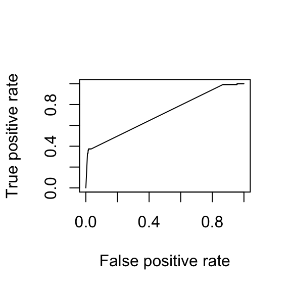

```r
# ROC curves
library(ROCR)
#par(mfrow=c(1, 2))
# prediction(predmodel.test.lda$posterior[,2], test$Y_is_oncologist) %>%
#   performance(measure = "tpr", x.measure = "fpr") %>%
#   plot()
prediction(predmodel.test.qda$posterior[,2], test$Y_is_oncologist) %>%
  performance(measure = "tpr", x.measure = "fpr") %>%
  plot()
```

```r
# model 1 AUC
prediction(predmodel.test.lda$posterior[,2], test$Y_is_oncologist) %>%
  performance(measure = "auc") %>%
  .@y.values
```

```
## [[1]]
## [1] 0.7074592
```

```r
# model 2 AUC
prediction(predmodel.test.qda$posterior[,2], test$Y_is_oncologist) %>%
  performance(measure = "auc") %>%
  .@y.values
```

```
## [[1]]
## [1] 0.7115156
```

The logistic regression and LDA methods are closely connected and differ primarily in their fitting procedures. Consequently, the two often produce similar results. However, LDA assumes that the observations are drawn from a Gaussian distribution with a common covariance matrix across each class of Y, and so can provide some improvements over logistic regression when this assumption approximately holds. Conversely, logistic regression can outperform LDA if these Gaussian assumptions are not met. Both LDA and logistic regression produce linear decision boundaries so when the true decision boundaries are linear, then the LDA and logistic regression approaches will tend to perform well. QDA, on the other-hand, provides a non-linear quadratic decision boundary. Thus, when the decision boundary is moderately non-linear, QDA may give better results.

LDA and QDA work well when class separation and normality assumption holds true in the dataset. If the dataset is not normal then Logistic regression has an edge over LDA and QDA model. Logistic regression does not work properly if the response classes are fully separated from each other. In general, logistic regression is used for binomial classification and in case of multiple response classes, LDA and QDA are more popular. And no one method will dominate the others in every situation. And often, we want to compare multiple approaches to see how they compare.